# Homework 2

Zinnia Nie

### Preliminaries

Code to read in data assumes: (1) that you have the following directories and files, where COURSE is the path to your top course directory; (2) that you have set the *hw03* directory to be your working directory; and (3) that you have installed the **tidyverse** package.

- Directories
  - COURSE/homework
  - COURSE/homework/hw03
  - COURSE/data
- Files
  - COURSE/homework/hw03/hw03.Rmd
  - COURSE/data/madison-weather-official-2020.csv
  - COURSE/data/exoplanets_default_2021-06-15.csv
  - COURSE/data/ORD-2017.csv
  - COURSE/data/ORD-2018.csv
  - COURSE/data/ORD-2019.csv
  - COURSE/data/ORD-2020.csv
  - COURSE/data/ORD-2021.csv
- Replace the text “YOUR NAME HERE” in the YAML section with your name.
- Edit this file, answer the questions, knit, and submit your solutions by uploading the resulting HTML file to the course Canvas site. Be sure to review your HTML and ensure that your solutions appear as you expect prior to submitting.

### Aims

- Practice data visualization using ggplot2
- Practice data wrangling with dplyr
- Practice reading in data and working with dates

### Problems

The following R chunk reads in the default exoplanets data, selects some variables, and changes some variable names.

```r
## Read in the csv file
## Select some variables that we will work with and rename them
## Note that the file begins with 100 meta-data lines that this code skips
## The argument `comment = "#"` fails as the symbol '#' appears in some of the websites included in the data set which are then interpreted as comments, preventing the full case to be read in as data
planets = read_csv("../../data/exoplanets_default_2021-06-15.csv",
                   skip = 100) %>%
  select(pl_name, hostname, discoverymethod,
         disc_year, sy_pnum, pl_rade, pl_bmasse) %>%
  rename(planet = pl_name,
         star = hostname,
         method = discoverymethod,
         year = disc_year,
         number = sy_pnum,
         radius = pl_rade,
         mass = pl_bmasse)
```

### 1

Using the exoplanet data table `planets`, filter so that you only use planets discovered by the radial velocity method. Remove cases where either of the variables `year` or `mass` (or both) are missing.

Create a table with a data summary with the number of planets discovered and the minimum mass of these planets by year.

Then make a scatterplot of the data such that (i) the size of points are proportional to the number of planets discovered that year (hint: add the aesthetic `size=` inside `aes()` and set it equal to your number of planets discovered column in your summary table), (ii) the y-axis is on the log10 scale (hint: add on `+scale_y_continuous()` as a layer), (iii) the axes have descriptive labels, (iv) and the plot contains an informative title.

In addition to the graphic, respond to the question below the R chunk.

```r
### Add your code here
radial_summary <- planets %>% filter(method == "Radial Velocity") %>%
  drop_na(year) %>% drop_na(mass) %>%
  group_by(year) %>%
  summarise(num_planets = length(planet), min_mass=min(mass))

radial_summary
```

```
## # A tibble: 28 × 3
##     year num_planets min_mass
##    <dbl>       <int>    <dbl>
##  1  1989           1   3398.
##  2  1995           1    150.
##  3  1996           6    219.
##  4  1997           1    332.
##  5  1998           6    166.
##  6  1999          13    156.
##  7  2000          16     71.8
##  8  2001          12    172.
##  9  2002          28     31.8
## 10  2003          21     72.5
## # ℹ 18 more rows
```

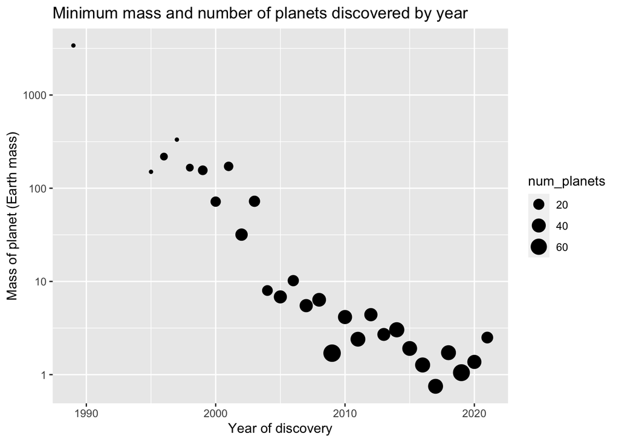

```r
ggplot(data=radial_summary, mapping=aes(x=year, y=min_mass, size=num_planets)) +
  geom_point() +
  scale_y_continuous(trans='log10') +
  xlab("Year of discovery") +
  ylab("Mass of planet (Earth mass)") +
  ggtitle("Minimum mass and number of planets discovered by year")
```

**Describe the trend between year and minimum mass of planet discovered using Radial Velocity.**

As time went on, the minimum mass of the planets discovered decreased. In other words, the Radial Velocity technology was able to detect planets of lower and lower mass compared to the past.

### 2

Using the `planets` data set created at the beginning of the assignment, determine which methods have been used to discover fewer than 20 planets each. Remove the planets discovered by those methods (with fewer than 20 exoplanet discoveries), and for the remaining planets, summarize *for each year*, the number of planets and the proportion of planets discovered by each method. **Proportions should sum to one in each year**.

This data summary should have one row for each year and method (if the method was used in that year) and columns with the names `year`, `method`, `n`, and `proportion`. Arrange the data summary by year, with the earliest years at the top of the table. *(Hint: you may find it helpful to create a `total` column with the total number of exoplanets discovered each year repeated for each row to help calculate the proportion.)*

(Extra hints: First, identify which methods had more than 20 discoveries, then filter out the original dataset to only discoveries made using those methods. Then, group by both year and method and tally to get the counts (since you want to look at how many were discovered by each method in each year) and use a sum in a mutate to find the total number of discoveries in each year (note this sum will run in each group and add a column with this). Then, divide in another mutate to find the proportion each method accounted for in each year, and you should have the desired data frame. You can then arrange and plot this.)

```r
more_than_20 <- planets %>% group_by(method) %>% filter(n()>20) %>%
  group_by(year, method) %>%
  summarise(n = sum(number)) %>%
  mutate(proportion = n / sum(n)) %>%
  arrange(year)
```

#### 2A

Report the dimensions of this data summary. Print the first 10 rows and all columns.

```r
dim(more_than_20)
```

```
## [1] 89  4
```

```r
more_than_20[1:10,]
```

```
## # A tibble: 10 × 4
## # Groups:   year [9]
##     year method              n proportion
##    <dbl> <chr>           <dbl>      <dbl>
##  1  1989 Radial Velocity     1     1
##  2  1995 Radial Velocity     1     1
##  3  1996 Radial Velocity    14     1
##  4  1997 Radial Velocity     2     1
##  5  1998 Radial Velocity    12     1
##  6  1999 Radial Velocity    19     1
##  7  2000 Radial Velocity    28     1
##  8  2001 Radial Velocity    18     1
##  9  2002 Radial Velocity    41     0.976
## 10  2002 Transit             1     0.0238
```

There are **89** rows and **4** columns.

#### 2B

Using the data summary, create and display a bar plot with the year on the x axis and the proportion of discovered planets on the y axis. Let each year have a single bar that extends from a proportion of 0 to 1, with sections of each bar filled with a color by method according to the proportion of exoplanets each method discovered in that year. Add appropriate axis labels and plot title.

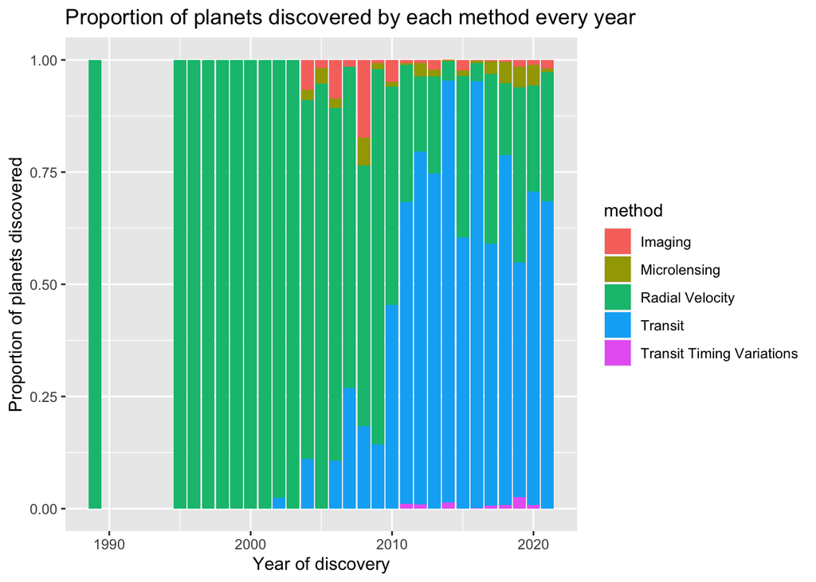

```r
ggplot(data=more_than_20, mapping = aes(x=year, y=proportion)) +
  geom_col(aes(fill=method)) +
  xlab("Year of discovery") +
  ylab("Proportion of planets discovered") +
  ggtitle("Proportion of planets discovered by each method every year")
```

#### 2C

Which method was most successful with the earliest discoveries of exoplanets, and which method has supplanted that method in relative popularity in recent years?

**Radial Velocity** was the most popular method of discovery in earlier years, but in recent years, **Transit** has gained more popularity.

### 3

Using only planets for which the radius has been estimated (i.e. radius is not missing), create a table that shows *for each year* the number of planets, the minimum radius, the median radius, and the maximum radius. Then, make a visualization of this table showing the following:

Using this table, create a graphic that has the following:

- Radius summaries on the y axis and discovery year on the x axis
- Add a line plot with blues lines connecting the maximum radius by year
- Add a line plot with purple lines connecting the median radius by year
- Add a line plot with red lines connecting the minimum radius by year
- Median radius versus year displayed as points with the size of each point proportional to the number of observations from that year
- Add appropriate axis labels and plot title.

```r
## Add your code here
has_radius <- planets %>% drop_na(radius) %>% group_by(year) %>%
  summarise(num_planets = length(planet), min_radius = min(radius), median_radius = median(radius), max_radius = max(radius))

has_radius
```

```
## # A tibble: 21 × 5
##     year num_planets min_radius median_radius max_radius
##    <dbl>       <int>      <dbl>         <dbl>      <dbl>
##  1  1999           1      15.6           15.6       15.6
##  2  2001           1      12.0           12.0       12.0
##  3  2002           1      15.3           15.3       15.3
##  4  2004           8       1.88          12.5       33.6
##  5  2005           2       8.30          10.5       12.7
##  6  2006           6       9.08          12.7       15.2
##  7  2007          17       9.98          14.8       24.7
##  8  2008          20       4.36          13.7       21.7
##  9  2009          18       1.68          13.7       21.0
## 10  2010          49       1.64          12.2       17.9
## # ℹ 11 more rows
```

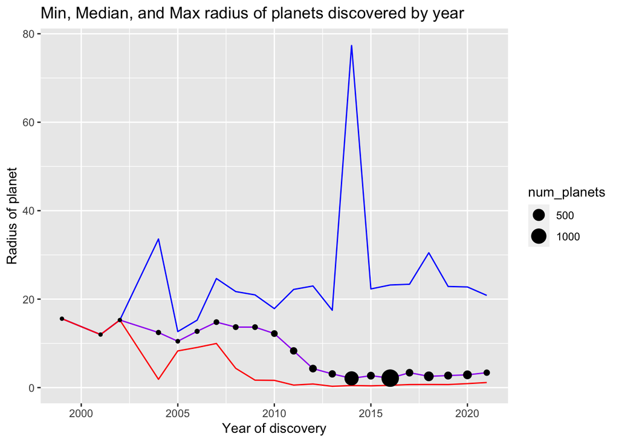

```r
ggplot(data=has_radius, mapping = aes(x=year, y=radius)) +
  geom_line(mapping=aes(y=max_radius), color = "blue") +
  geom_line(mapping=aes(y=median_radius), color = "purple") +
  geom_line(mapping=aes(y=min_radius), color = "red") +
  geom_point(mapping=aes(y=median_radius, size=num_planets)) +
  xlab("Year of discovery") +
  ylab("Radius of planet") +
  ggtitle("Min, Median, and Max radius of planets discovered by year")
```

### 4

A small number of planets have both an estimated mass AND an estimated radius less than those of the Earth. What are the names of these planets, what method(s) were used to detect them, and in what year were they discovered?

- Create a data summary table with the star name, planet name, method, year, mass, and radius of the planets that have **both** an estimated mass < 1 Earth mass and an estimated radius < 1 Earth radius.
- Order the rows increasing by mass.
- Print the entire table.

```r
## Add your code here
smaller_than_earth <- planets %>% drop_na(mass, radius) %>% filter(mass<1 & radius<1)

smaller_than_earth
```

```
## # A tibble: 6 × 7
##   planet       star       method                        year number radius  mass
##   <chr>        <chr>      <chr>                        <dbl>  <dbl>  <dbl> <dbl>
## 1 K2-266 c     K2-266     Transit                       2018      4  0.705 0.290
## 2 KOI-55 b     KOI-55     Orbital Brightness Modulati…  2011      2  0.759 0.44
## 3 KOI-55 c     KOI-55     Orbital Brightness Modulati…  2011      2  0.867 0.655
## 4 Kepler-138 b Kepler-138 Transit                       2014      3  0.522 0.066
## 5 TRAPPIST-1 d TRAPPIST-1 Transit                       2016      7  0.772 0.41
## 6 TRAPPIST-1 e TRAPPIST-1 Transit                       2017      7  0.918 0.62
```

### 5

Use the official Madison weather data (`madison-weather-official-2020.csv`).

For each date where there is no missing data for precipitation (`prpc`) or average temperature (`tavg`), define a new variable called `any_prcp` so that `any_prcp` is “Precipitation” for dates when there is precipitation and `any_prcp` is “No precipitation” on dates when there is no precipitation.

(Hint: Try the `ifelse()` function in a mutate, and use `prcp==0` as the test condition (don’t forget to set the appropriate values that are returned if the condition is true or false). See [link1](https://www.datamentor.io/r-programming/ifelse-function/) or [link2](https://www.programiz.com/r/ifelse-function) for more details.)

For each year, calculate the average temperature for all the days that had precipitation and the average temperature for all the days that did not have any precipitation.

Display a scatterplot of with these averages on the y-axis versus year on the x-axis. Color the points based on their value of `any_prcp`. Add clear axis labels and a descriptive title. Note: you can remove the legend label with `labs(color=NULL)`.

```r
official = read_csv("../../data/madison-weather-official-2020.csv")

# insert rest of your code below
precipt <- official %>% drop_na(prcp, tavg) %>%
  mutate(any_prcp = ifelse(prcp==0, "No Precipitation", "Precipitation")) %>%
  mutate(year = year(date)) %>%
  group_by(year, any_prcp) %>%
  summarise(avg_temp = mean(tavg))

precipt
```

```
## # A tibble: 304 × 3
## # Groups:   year [152]
##     year any_prcp         avg_temp
##    <dbl> <chr>               <dbl>
##  1  1869 No Precipitation     41.8
##  2  1869 Precipitation        50.4
##  3  1870 No Precipitation     47.5
##  4  1870 Precipitation        49.2
##  5  1871 No Precipitation     46.2
##  6  1871 Precipitation        46.4
##  7  1872 No Precipitation     43.4
##  8  1872 Precipitation        46.7
##  9  1873 No Precipitation     43.8
## 10  1873 Precipitation        45.0
## # ℹ 294 more rows
```

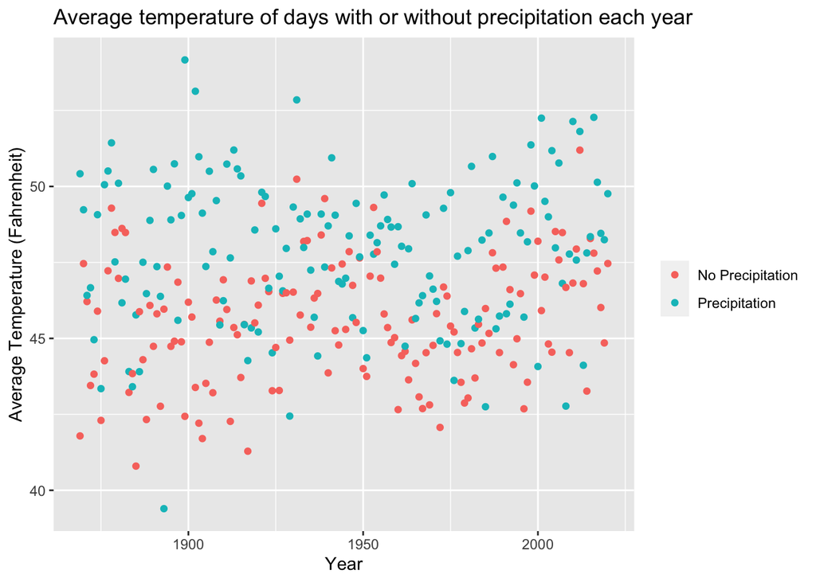

```r
ggplot(data = precipt, mapping = aes(x=year, y=avg_temp)) +
  geom_point(aes(color=any_prcp)) +
  xlab("Year") +
  ylab("Average Temperature (Fahrenheit)") +
  labs(color=NULL) +
  ggtitle("Average temperature of days with or without precipitation each year")
```

### 6

Use the official Madison weather data (`madison-weather-official-2020.csv`).

#### 6A

The code below determines the average maximum and minimum temperatures for each day of the year for the period from 2001 – 2020.

```r
temp = official %>%
  mutate(year = year(date),
         month = month(date, label = TRUE),
         day = day(date)) %>%
  filter(year >= 2001) %>%
  group_by(month, day) %>%
  summarize(tmax = mean(tmax),
            tmin = mean(tmin))
```

Graph these values with line plots, one for maximum using red lines, one for minimum using blue lines, for each day of the month with a different facet for each month of the year. Add clear axis labels and a descriptive title.

```r
# insert code here
temp
```

```
## # A tibble: 366 × 4
## # Groups:   month [12]
##    month   day  tmax  tmin
##    <ord> <int> <dbl> <dbl>
##  1 Jan       1  27.4  10.9
##  2 Jan       2  27.6  12.6
##  3 Jan       3  29.8  13.2
##  4 Jan       4  30.2  14.2
##  5 Jan       5  28.9  12.9
##  6 Jan       6  26.9  12.5
##  7 Jan       7  30.0  14.2
##  8 Jan       8  30.2  13.2
##  9 Jan       9  31.2  13.4
## 10 Jan      10  32.5  14.4
## # ℹ 356 more rows
```

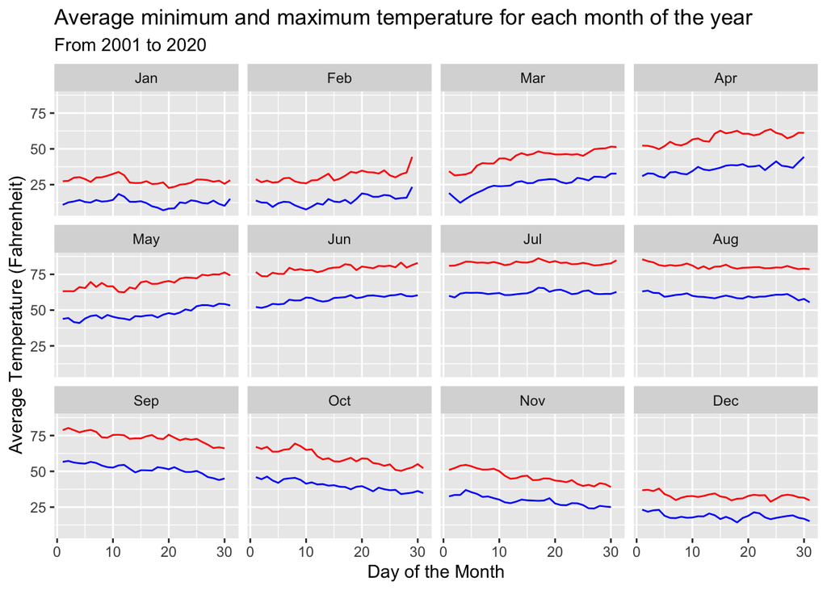

```r
ggplot(data=temp, aes(x=day)) +
  geom_line(mapping=aes(y=tmax), color = "red") +
  geom_line(mapping=aes(y=tmin), color = "blue") +
  facet_wrap(~month) +
  xlab("Day of the Month") +
  ylab("Average Temperature (Fahrenheit)") +
  ggtitle("Average minimum and maximum temperature for each month of the year", subtitle = "From 2001 to 2020")
```

#### 6B

Find the five days of the year which have the smallest differences between the average high and low temperatures using data from 2001 – 2020. Display these values (i.e., month, day, average high temperature, average low temperature, and the difference) in a table, ordered with the smallest differences at the top.

(Hint: Create a new column showing the differences, then use `slice_min()` with the appropriate `n=` argument value.)

```r
smallest <- temp %>% mutate(diff = (tmax-tmin)) %>% ungroup() %>% slice_min(diff, n=5)

smallest
```

```
## # A tibble: 5 × 5
##   month   day  tmax  tmin  diff
##   <ord> <int> <dbl> <dbl> <dbl>
## 1 Dec      21  33.6  21.4  12.2
## 2 Dec      24  28.8  16.6  12.2
## 3 Jan      24  26.4  14.0  12.3
## 4 Jan      22  25    12.6  12.4
## 5 Dec      22  33.2  20.7  12.5
```

### Preprocessing for question 7-9 (Already done for you!)

The next questions involves five data sets of international flights arriving to Chicago’s O’Hare airport from January 1, 2017 through December 31, 2021 with one separate file for each year. Each file has been cleaned from the original HTML.

We have done the following preprocessing steps for you, but *please read the code carefully and run it yourself line by line to make sure you understand what it’s doing and how it works!* - Read in the five data sets. - Use `bind_rows()` to combine these data sets into a single data set. Note that you may need to adjust the format for some of the variables (e.g., `date`) for consistency among the data sets. - Add columns for *year*, *month* (character valued, use month abbreviations, Jan-Dec), *day* (day of the month), and *wday* (day of the week, character valued, use day abbreviations, Sun - Sat). - Reorder the variables so that these new variables all appear directly after the date column. - Remove the terminal variable. - Rename *all_total* to *passengers*, *all_flights* to *flights*, and *all_booths* to *booths*. - Arrange the rows by date and hour. - Remove the individual data sets from each individual year (use `rm()`). - Print the first 5 rows of the data frame.

For the remaining questions, simply use the resulting `ord` data frame.

```r
ord2017 = read_csv("../../data/ORD-2017.csv")
ord2018 = read_csv("../../data/ORD-2018.csv",
                   col_names = names(ord2017), skip = 1) %>%
  mutate(date = mdy(date))
ord2019 = read_csv("../../data/ORD-2019.csv") %>%
  mutate(date = mdy(date))
ord2020 = read_csv("../../data/ORD-2020.csv")
ord2021 = read_csv("../../data/ORD-2021.csv")


ord = bind_rows(ord2017, ord2018, ord2019, ord2020, ord2021) %>%
  mutate(year=year(date),
         month=month(date, label=TRUE),
         day=day(date),
         wday=wday(date,label=TRUE)) %>%
  select(-terminal) %>%
  select(airport, date, year, month, day, wday, everything()) %>%
  arrange(date, hour) %>%
  rename(passengers = all_total,
         flights = all_flights,
         booths = all_booths)

rm(ord2017, ord2018, ord2019, ord2020, ord2021)

dim(ord)
```

```
## [1] 31344    24
```

```r
ord %>% print(n=5)
```

```
## # A tibble: 31,344 × 24
##   airport date        year month   day wday  hour        us_avg_wait us_max_wait
##   <chr>   <date>     <dbl> <ord> <int> <ord> <chr>             <dbl>       <dbl>
## 1 ORD     2017-01-01  2017 Jan       1 Sun   0700 - 0800           7          24
## 2 ORD     2017-01-01  2017 Jan       1 Sun   0800 - 0900           5          25
## 3 ORD     2017-01-01  2017 Jan       1 Sun   0900 - 1000           5          37
## 4 ORD     2017-01-01  2017 Jan       1 Sun   1000 - 1100           8          20
## 5 ORD     2017-01-01  2017 Jan       1 Sun   1100 - 1200          30          89
## # ℹ 31,339 more rows
## # ℹ 15 more variables: non_us_avg_wait <dbl>, non_us_max_wait <dbl>,
## #   all_avg_wait <dbl>, all_max_wait <dbl>, all_n_0_15 <dbl>,
## #   all_n_16_30 <dbl>, all_n_31_45 <dbl>, all_n_46_60 <dbl>, all_n_61_90 <dbl>,
## #   all_n_91_120 <dbl>, all_n_120_plus <dbl>, all_excluded <dbl>,
## #   passengers <dbl>, flights <dbl>, booths <dbl>
```

### 7

Are there any dates in the range from January 1, 2017 through December 31, 2021 that are missing? If so, how many days? (Bonus: which ones?)

```r
temp = tibble(
  date = seq(ymd("2017-01-01"), ymd("2021-12-31"), 1)
)

temp %>% anti_join(ord)
```

```
## # A tibble: 5 × 1
##   date
##   <date>
## 1 2018-05-08
## 2 2019-10-28
## 3 2019-10-29
## 4 2019-10-30
## 5 2020-02-08
```

**5** days are missing. They are 2018-05-08, 2019-10-28, 2019-10-29, 2019-10-30, 2020-02-08.

### 8

> Analysis of monthly international arrivals.

#### 8A

- Display the total number of passengers by month and year with a bar chart where month is the primary variable on the x-axis and there is a separate bar (i.e, not stacked) and filled with a different color for each year.  
  (Hint: You can do this by setting `fill=as.character(year)` as an aesthetic inside `aes()` (this uses it as a group differentiated by fill color, and sets the coloring method to be categorical instead of numeric (which gives nicer contrast)); and then adding `+geom_col(position = "dodge")` as a plot layer, which creates the unstacked bar plot. (Note `geom_col()` and `geom_bar()` do different things (see help page for more details on this)))
- Add meaningful axis labels and a title to this graph.
- Change the scale on the y axis so that values are printed as numbers with commas and not using scientific notation. (See the help for the **ggplot2** function `scale_y_continuous()` and the **scales** function `label_comma()`.)

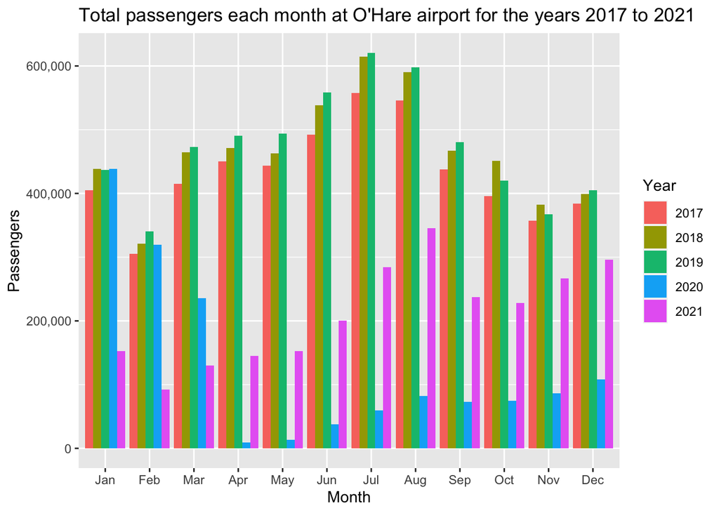

```r
ggplot(data = ord %>% group_by(year, month) %>% summarise(total = sum(passengers)), mapping = aes(x=month, y=total, fill=as.character(year))) +
  geom_col(position = "dodge") +
  scale_y_continuous(labels = label_comma()) +
  xlab("Month") +
  ylab("Passengers") +
  labs(fill="Year") +
  ggtitle("Total passengers each month at O'Hare airport for the years 2017 to 2021")
```

#### 8B

In the 2020 and 2021 months, how do the passenger totals compare to the previous years? Describe any other patterns you notice.

In 2020, the passenger totals dipped drastically after March, which lines up with the lockdown time due to COVID-19. Then, in the later months of 2021, the passenger total climbs back up again, but it does not reach the levels of the years 2017-2019.

### 9

> Investigate the average number of passengers per day of the week.

#### 9A

- Create a table that contains the average number of passengers arriving for each day of the week (Sun - Sat) for each year (2017–2021). (This table should have three columns: the year, the day of the week, and the number of passengers.)  
  (Hint: make sure to group by year and wday before applying the appropriate summary function)
- Create a graphic that displays a bar for each day of the week with the height of the bar at the average number of passengers for that day of the week with a separate facet for each year.  
  (Hint: again, make sure you use `geom_col()` instead of `geom_bar()` here (make sure you understand the difference between these two!). Also, `facet_wrap(~year)` allows you to easily facet on year.)
- Add descriptive axis labels and a title.

```r
weekly <- ord %>% group_by(year, wday) %>% summarise(avg_passengers = sum(passengers)/length(wday))

weekly
```

```
## # A tibble: 35 × 3
## # Groups:   year [5]
##     year wday  avg_passengers
##    <dbl> <ord>          <dbl>
##  1  2017 Sun             836.
##  2  2017 Mon             783.
##  3  2017 Tue             690.
##  4  2017 Wed             720.
##  5  2017 Thu             728.
##  6  2017 Fri             769.
##  7  2017 Sat             881.
##  8  2018 Sun             874.
##  9  2018 Mon             796.
## 10  2018 Tue             727.
## # ℹ 25 more rows
```

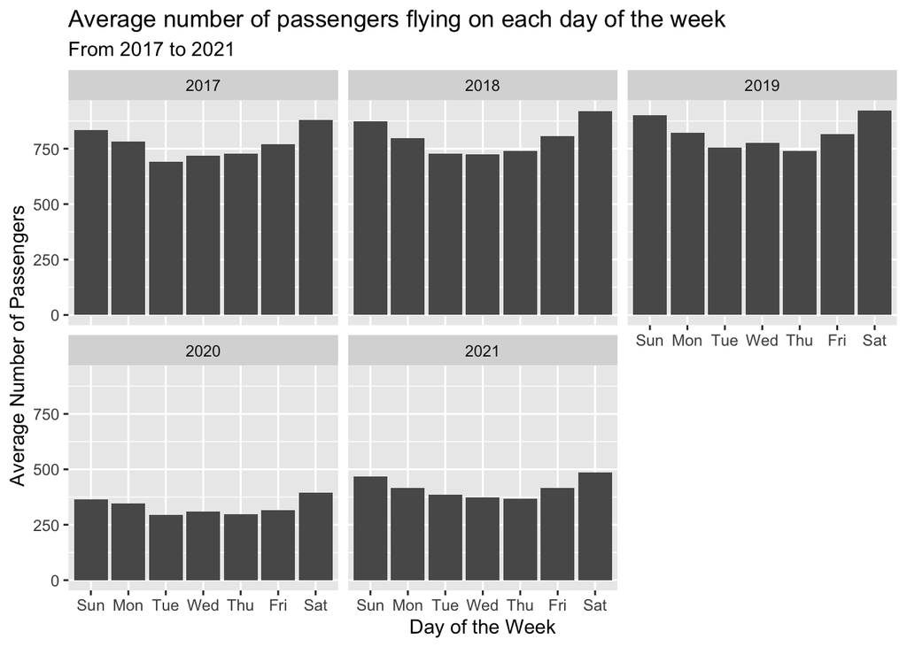

```r
ggplot(data=weekly, mapping=aes(x=wday, y=avg_passengers)) +
  geom_col() +
  facet_wrap(~year) +
  xlab("Day of the Week") +
  ylab("Average Number of Passengers") +
  ggtitle("Average number of passengers flying on each day of the week", subtitle = "From 2017 to 2021")
```

#### 9B

Which day of the week has the highest average number of passengers for each year? Hint: consider using `slice_max()`.

```r
weekly %>% slice_max(avg_passengers, n=1)
```

```
## # A tibble: 5 × 3
## # Groups:   year [5]
##    year wday  avg_passengers
##   <dbl> <ord>          <dbl>
## 1  2017 Sat             881.
## 2  2018 Sat             918.
## 3  2019 Sat             923.
## 4  2020 Sat             394.
## 5  2021 Sat             486.
```

For each year, the day with the highest average number of passengers is **Saturday**.

#### 9C

Which day of the week has the lowest average number of passengers for each year? Hint: consider using `slice_min()`.

```r
weekly %>% slice_min(avg_passengers, n=1)
```

```
## # A tibble: 5 × 3
## # Groups:   year [5]
##    year wday  avg_passengers
##   <dbl> <ord>          <dbl>
## 1  2017 Tue             690.
## 2  2018 Wed             726.
## 3  2019 Thu             739.
## 4  2020 Tue             294.
## 5  2021 Thu             366.
```

**Tuesday and Thursday** appear the same amount of times as the day with the lowest average number of passengers for each year. In general, it seems like the middle of the week, Tues, Wed, Thurs, has the lowest average number of fliers.